# Final-Proj

Deo Shaji

2025-04-26

# Analysis of Diabetes Health Indicators

Deo Shaji

## Introduction

The goal of this project is to explore the Diabetes Health Indicators Dataset to find out which variables or combination of variable are great at modeling the chances a person has diabetes. As the number of people with diabetes is growing significantly, it is important to understand what variables are great indicators of diabetes.This understanding of what indicators relate to diabetes can help with the learning what causes diabetes or how to prevent diabetes in the future.

We will look at the following questions:

1. Which variables are highly correlated to having diabetes?
2. Can smoking status or alcohol consumption predict diabetes?
3. Does diet affect chances of diabetes?
4. Does Mental health, Physical Health, education, and income affect chances of diabetes?
5. Can we predict a model that can accurately predict diabetes?

## Data

### Structure

The link to the dataset is https://www.kaggle.com/datasets/alexteboul/diabetes-health-indicators-dataset. This is a dataset from Kaggle containing data collected by survey from 400,000 Americans. This data was collected by the CDC as part of their Behavioral Risk Factor Surveillance System(BRFSS). The dataset provided by kaggle is a cleaned up version of the original survey for the year 2015. There are three csv files provided but we will only be looking at the first csv file that contains 253,680 survey responses with a binary categorization of 0 for no diabetes and 1 for pre diabetes or diabetes. The other files will not be used in this analysis.

### Cleaning

This data set contains 253,680 responses with 22 variables in total. We will go through the data set to remove any rows that have empty values, then remove the variables deemed unnecessary.

```r
library(tidyverse)
# load data set
data <- read.csv("diabetes_binary_health_indicators_BRFSS2015.csv")
View(data)

# remove any records with empty values
data <- data %>%
  drop_na()

# check to see if any rows were deleted
nrow(data)
```

```
## [1] 253680
```

It seems that there were no empty cells in this data set. Now we will go through all the variables and delete the ones deemed unnecessary.

```r
colnames(data)
```

```
##  [1] "Diabetes_binary"      "HighBP"               "HighChol"
##  [4] "CholCheck"            "BMI"                  "Smoker"
##  [7] "Stroke"               "HeartDiseaseorAttack" "PhysActivity"
## [10] "Fruits"               "Veggies"              "HvyAlcoholConsump"
## [13] "AnyHealthcare"        "NoDocbcCost"          "GenHlth"
## [16] "MentHlth"             "PhysHlth"             "DiffWalk"
## [19] "Sex"                  "Age"                  "Education"
## [22] "Income"
```

Cholcheck, AnyHealthcare, and NoDocbcCost are the three variables I plan to remove. Cholcheck is a variable that returns 0 if the individual has not checked their cholesterol in the past five years and returns 1 if they have had a cholesterol check. Only 9,000 responded with 0 for this variable implying the insignificance of Cholcheck. The same issue occurred with the other two variables where only a small proportion of people claimed they did not have any health insurance or that they did not go see a doctor due to the costs.

```r
# remove unnecessary columns
data <- data |>
  select(-CholCheck, -AnyHealthcare, -NoDocbcCost)

# check if columns were removed
ncol(data)
```

```
## [1] 19
```

### Variables

- Diabetes_binary: 0 for no diabetes, 1 for pre diabetic or diabetic
- HighBP: 0 = no high BP, 1 = high BP
- HighChol: 0 = no high cholesterol, 1 = high cholesterol
- BMI: Body Mass Index
- Smoker: Have you smoked at least 100 cigarettes in your entire life? [Note: 5 packs = 100 cigarettes] 0 = no 1 = yes
- Stroke: you had a stroke. 0 = no 1 = yes
- HeartDiseaseorAttack: coronary heart disease (CHD) or myocardial infarction (MI) 0 = no 1 = yes
- PhysActivity: physical activity in past 30 days - not including job 0 = no 1 = yes
- Fruits: Consume Fruit 1 or more times per day 0 = no 1 = yes
- Veggies: Consume Vegetables 1 or more times per day 0 = no 1 = yes
- HvyAlcoholConsump: Heavy drinkers (adult men having more than 14 drinks per week and adult women having more than 7 drinks per week) 0 = no 1 = yes
- GenHlth: Would you say that in general your health is: scale 1-5 1 = excellent 2 = very good 3 = good 4 = fair 5 = poor
- MentHlth: Now thinking about your mental health, which includes stress, depression, and problems with emotions, for how many days during the past 30 days was your mental health not good? scale 1-30 days
- PhysHlth: Now thinking about your physical health, which includes physical illness and injury, for how many days during the past 30 days was your physical health not good? scale 1-30 days
- DiffWalk: Do you have serious difficulty walking or climbing stairs? 0 = no 1 = yes
- Sex: 0 = female 1 = male
- Age: 13-level age category. 1 = 18-24, 2 = 25 - 29, 3 = 30 - 34, 4 = 35 - 39, 5 = 40 - 44, 6 = 45 - 49, 7 = 50 - 54, 8 = 55 - 59, 9 = 60-64, 10 = 65 - 69, 11 = 70 - 74, 12 = 75 - 79, 13 = 80 or older
- Education: Education level scale 1-6: 1 = Never attended school or only kindergarten 2 = Grades 1 through 8 (Elementary) 3 = Grades 9 through 11 (Some high school) 4 = Grade 12 or GED (High school graduate) 5 = College 1 year to 3 years (Some college or technical school) 6 = College 4 years or more (College graduate)
- Income: Income scale 1-8. 1 = less than 10,000, 2 = 10,000 - 15,000, 3 = 15,000 - 20,000, 4 = 20,000 - 25,000, 5 = 25,000 - 35,000, 6 = 35,000 - 50,000, 7 = 50,000 - 75,000, 8 = 75,000 or more

Majority of these variables are categorical, but have been classified as num by R. I will update the variables to be represented as levels.

```r
# update variables from num to levels
data <- data |>
  mutate(
    Diabetes_binary = factor(Diabetes_binary),
    HighBP = factor(HighBP),
    HighChol = factor(HighChol),
    Stroke = factor(Stroke),
    Smoker = factor(Smoker),
    HeartDiseaseorAttack = factor(HeartDiseaseorAttack),
    PhysActivity = factor(PhysActivity),
    Fruits = factor(Fruits),
    Veggies = factor(Veggies),
    HvyAlcoholConsump = factor(HvyAlcoholConsump),
    GenHlth = factor(GenHlth),
    MentHlth = as.numeric(MentHlth),
    PhysHlth = as.numeric(PhysHlth),
    DiffWalk = factor(DiffWalk),
    Sex = factor(Sex),
    Education = factor(Education),
    Income = factor(Income),
    Age = factor(Age)
  )

# check if the variables changed
str(data)
```

```
## 'data.frame':    253680 obs. of  19 variables:
##  $ Diabetes_binary     : Factor w/ 2 levels "0","1": 1 1 1 1 1 1 1 1 2 1 ...
##  $ HighBP              : Factor w/ 2 levels "0","1": 2 1 2 2 2 2 2 2 2 1 ...
##  $ HighChol            : Factor w/ 2 levels "0","1": 2 1 2 1 2 2 1 2 2 1 ...
##  $ BMI                 : num  40 25 28 27 24 25 30 25 30 24 ...
##  $ Smoker              : Factor w/ 2 levels "0","1": 2 2 1 1 1 2 2 2 2 1 ...
##  $ Stroke              : Factor w/ 2 levels "0","1": 1 1 1 1 1 1 1 1 1 1 ...
##  $ HeartDiseaseorAttack: Factor w/ 2 levels "0","1": 1 1 1 1 1 1 1 1 2 1 ...
##  $ PhysActivity        : Factor w/ 2 levels "0","1": 1 2 1 2 2 2 1 2 1 1 ...
##  $ Fruits              : Factor w/ 2 levels "0","1": 1 1 2 2 2 2 1 1 2 1 ...
##  $ Veggies             : Factor w/ 2 levels "0","1": 2 1 1 2 2 2 1 2 2 2 ...
##  $ HvyAlcoholConsump   : Factor w/ 2 levels "0","1": 1 1 1 1 1 1 1 1 1 1 ...
##  $ GenHlth             : Factor w/ 5 levels "1","2","3","4",..: 5 3 5 2 2 2 3 3 5 2 ...
##  $ MentHlth            : num  18 0 30 0 3 0 0 0 30 0 ...
##  $ PhysHlth            : num  15 0 30 0 0 2 14 0 30 0 ...
##  $ DiffWalk            : Factor w/ 2 levels "0","1": 2 1 2 1 1 1 1 2 2 1 ...
##  $ Sex                 : Factor w/ 2 levels "0","1": 1 1 1 1 1 2 1 1 1 2 ...
##  $ Age                 : Factor w/ 13 levels "1","2","3","4",..: 9 7 9 11 11 10 9 11 9 8 ...
##  $ Education           : Factor w/ 6 levels "1","2","3","4",..: 4 6 4 3 5 6 6 4 5 4 ...
##  $ Income              : Factor w/ 8 levels "1","2","3","4",..: 3 1 8 6 4 8 7 4 1 3 ...
```

## Results

### Which variables are highly correlated to having diabetes?

#### Categorical Variables

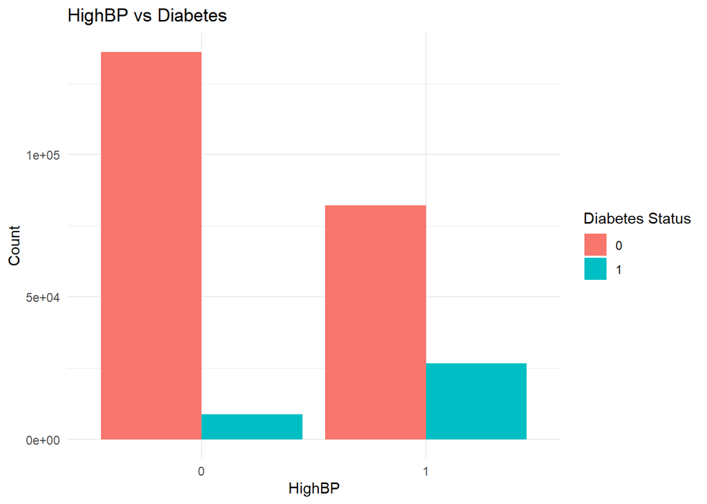

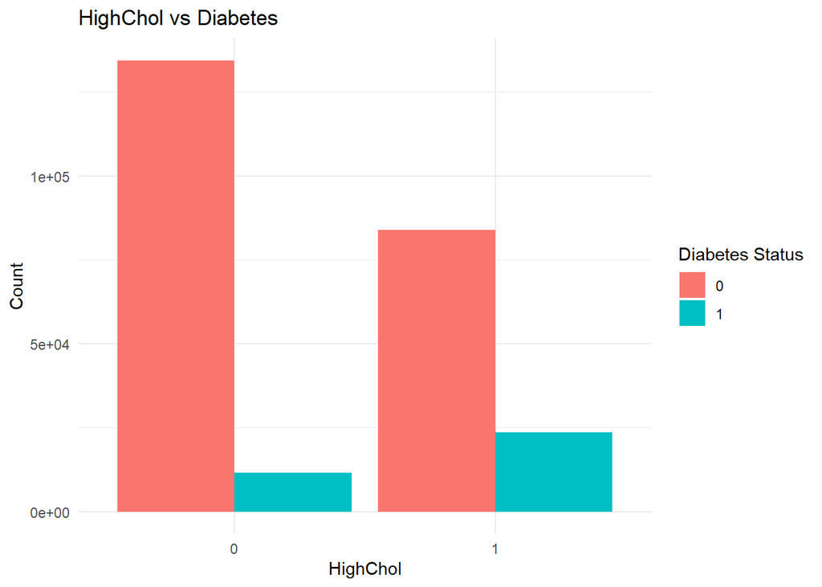

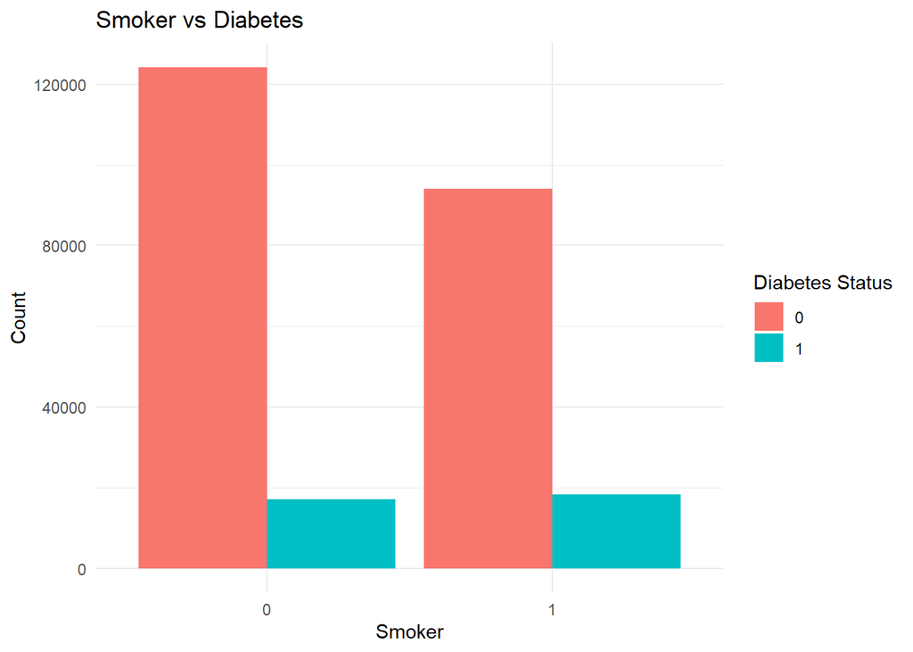

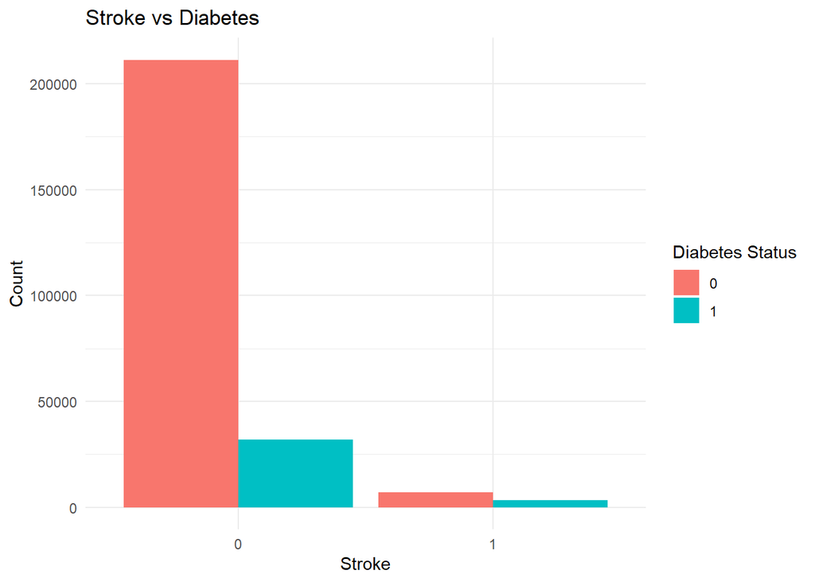

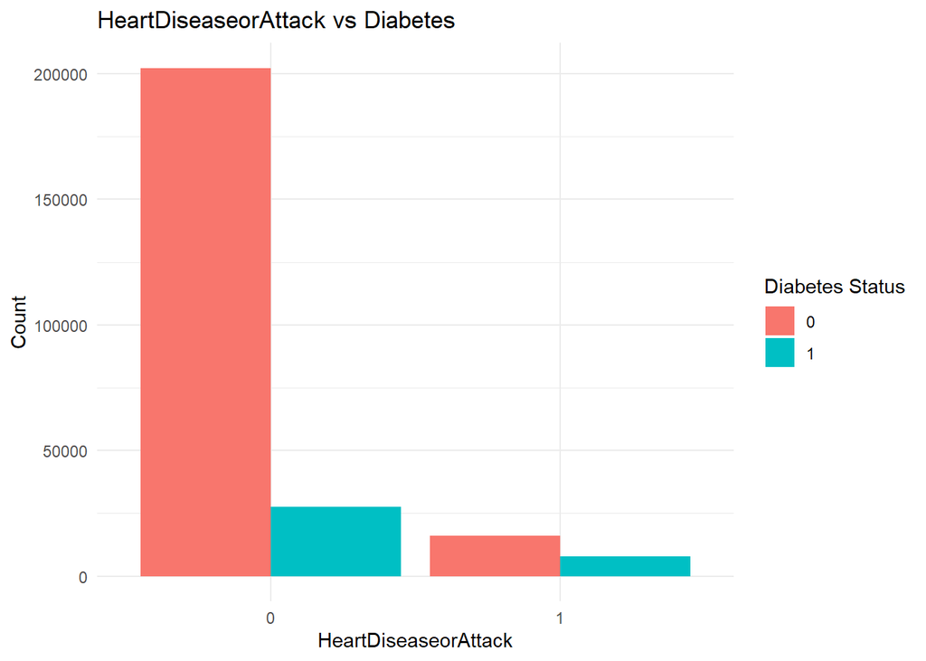

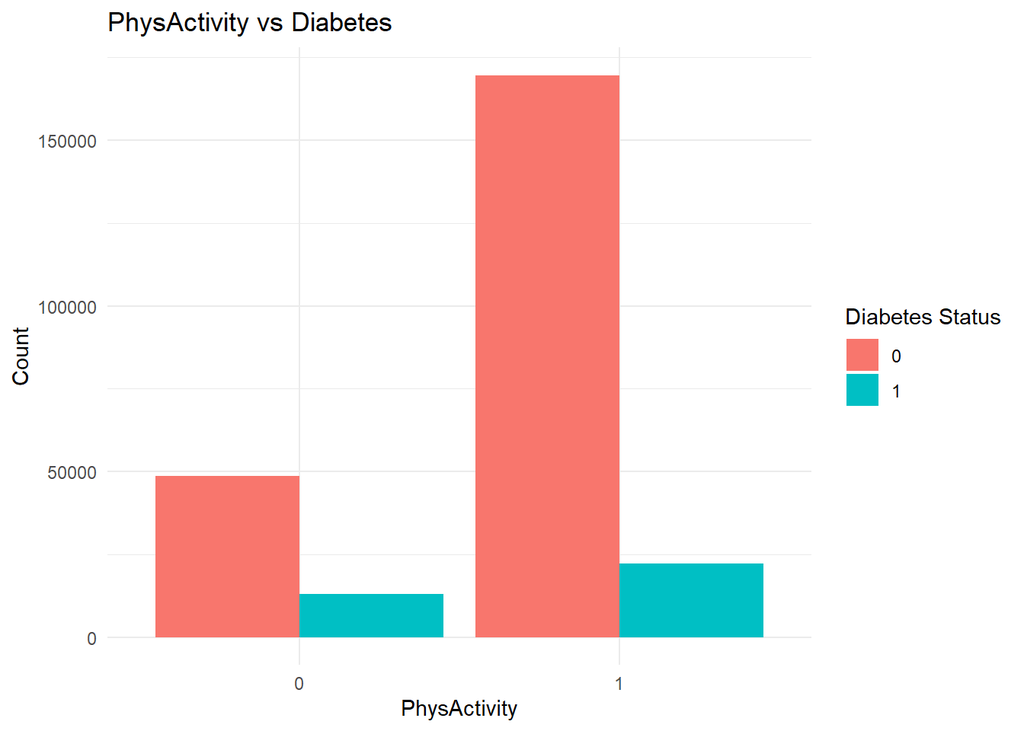

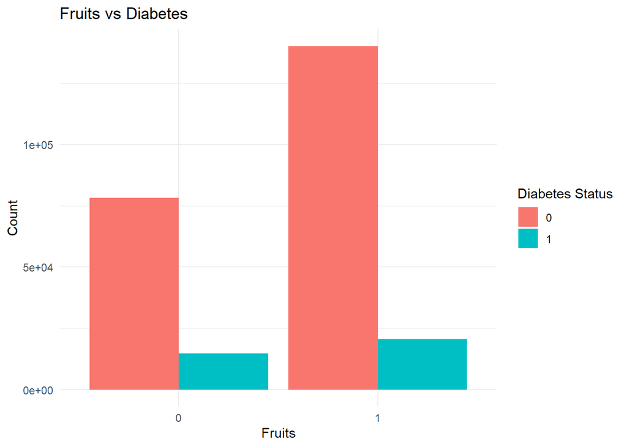

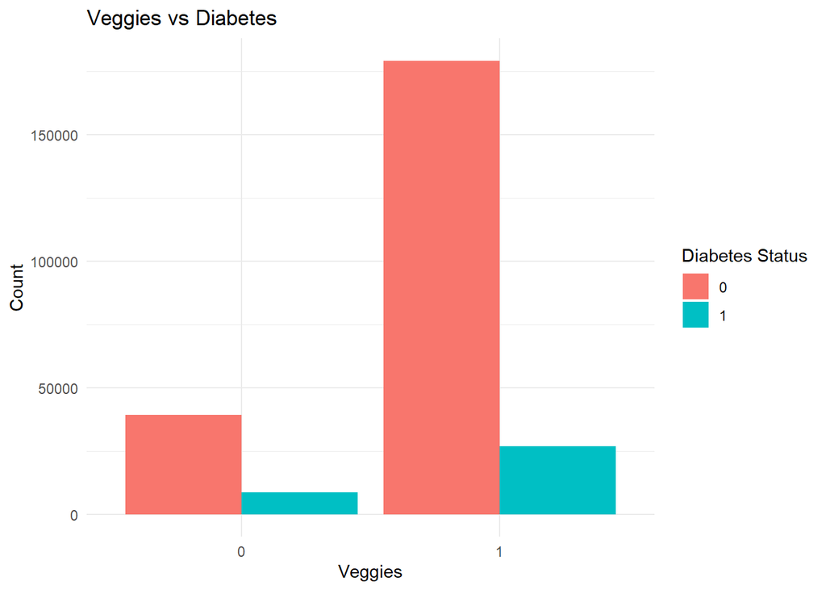

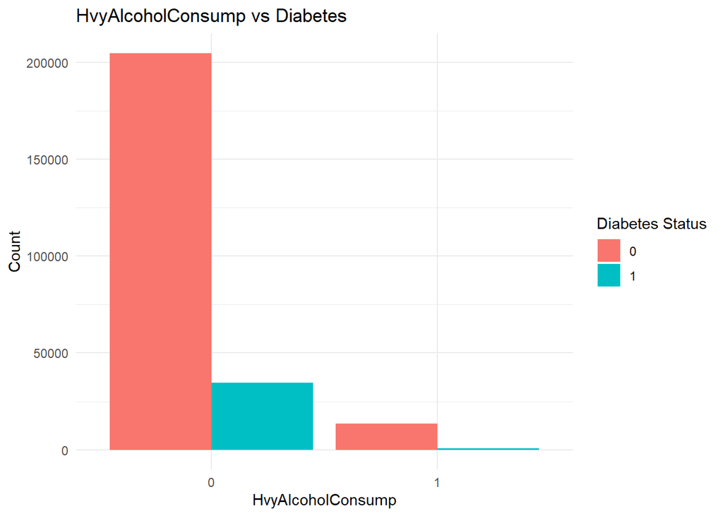

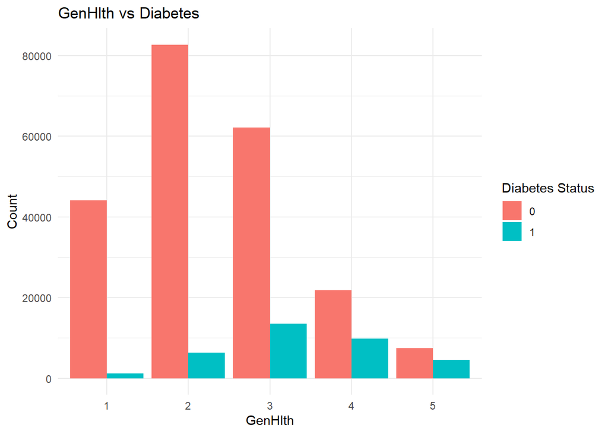

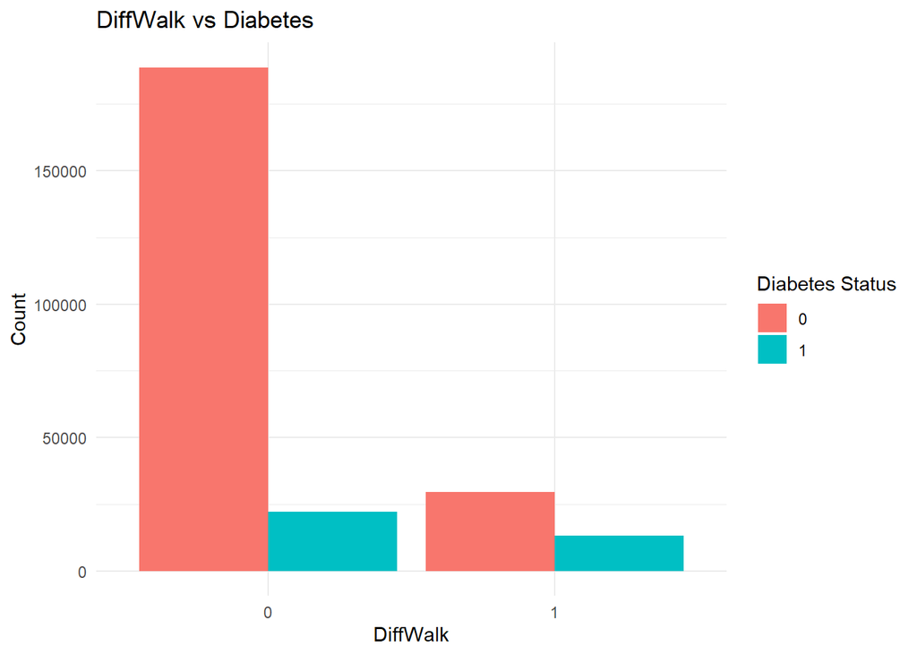

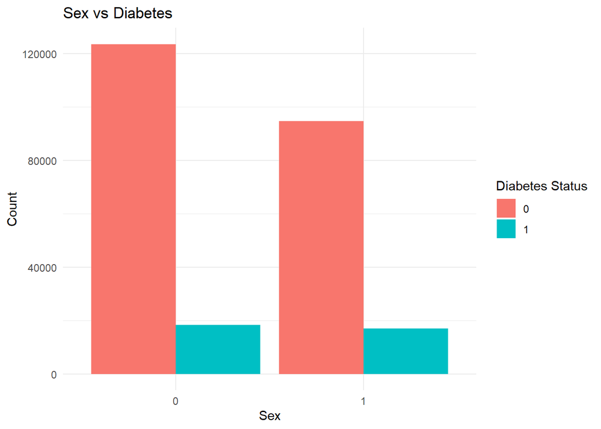

[3 more figures not shown]

```r
# List of categorical variables to plot
categorical_vars <- c("HighBP", "HighChol", "Smoker", "Stroke", "HeartDiseaseorAttack", "PhysActivity", "Fruits", "Veggies", "HvyAlcoholConsump", "GenHlth", "DiffWalk", "Sex", "Age", "Education", "Income")

for (var in categorical_vars) {
  print(
    data |>
      ggplot(aes_string(x = var, fill = "Diabetes_binary")) +
      geom_bar(position = "dodge") +
      labs(
        title = paste(var, "vs Diabetes"),
        x = var,
        y = "Count",
        fill = "Diabetes Status"
      ) +
      theme_minimal()
  )
}
```

What we want to look at is which variables have a high correlation with having diabetes.

Here are the list of categorical variables that correlate with having diabetes

#### Numerical Variables

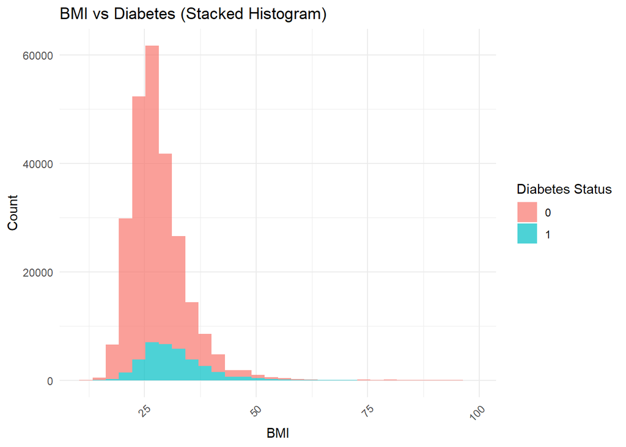

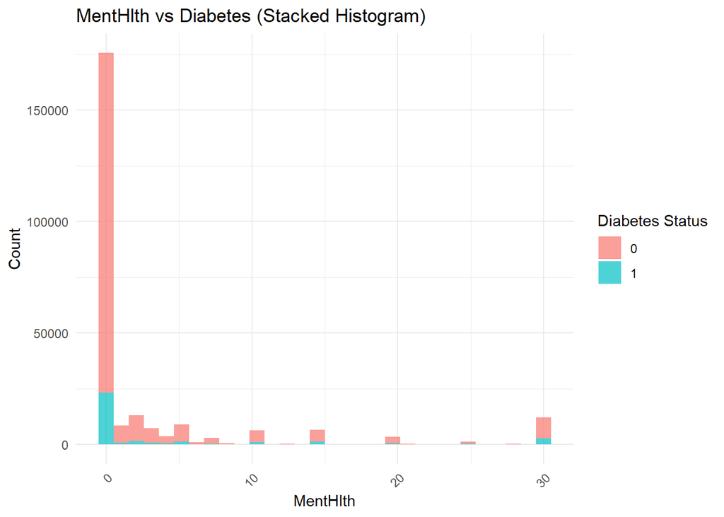

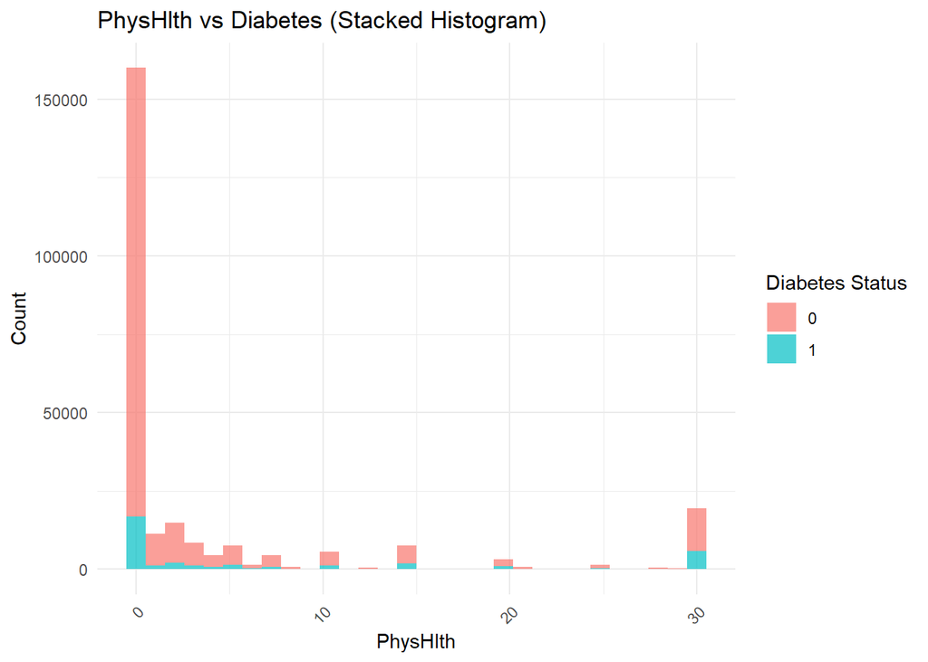

```r
# List of numerical variables to plot
numerical_vars <- c("BMI", "MentHlth", "PhysHlth")

for (var in numerical_vars) {
  print(
    data |>
      ggplot(aes_string(x = var, fill = "Diabetes_binary")) +
      geom_histogram(position = "stack", bins = 30, alpha = 0.7) +  # Stacked histogram
      labs(
        title = paste(var, "vs Diabetes (Stacked Histogram)"),
        x = var,
        y = "Count",
        fill = "Diabetes Status"
      ) +
      theme_minimal() +
      theme(axis.text.x = element_text(angle = 45, hjust = 1))  # Rotate x-axis text for readability
  )
}
```

### Can smoking status or alcohol consumption predict diabetes?

#### Smoking Status

```r
# Fit a logistic regression model for SmokingStatus as a predictor of Diabetes
model_smoking <- glm(Diabetes_binary ~ Smoker, data = data, family = "binomial")

# Summary of the model
summary(model_smoking)
```

```
##
## Call:
## glm(formula = Diabetes_binary ~ Smoker, family = "binomial",
##     data = data)
##
## Coefficients:
##              Estimate Std. Error z value Pr(>|z|)
## (Intercept) -1.987201   0.008171 -243.19   <2e-16 ***
## Smoker1      0.350609   0.011489   30.52   <2e-16 ***
## ---
## Signif. codes:  0 '***' 0.001 '**' 0.01 '*' 0.05 '.' 0.1 ' ' 1
##
## (Dispersion parameter for binomial family taken to be 1)
##
##     Null deviance: 204847  on 253679  degrees of freedom
## Residual deviance: 203916  on 253678  degrees of freedom
## AIC: 203920
##
## Number of Fisher Scoring iterations: 4
```

Here the p-value for smoker is <0.05 implying that the smoker variable is statistically significant. Smoker 1 has an estimate of 0.350609 which results in a positive relationship between smoking and having diabetes with a log odds of .35 or odds ratio of 1.41993202. What this means is that the chances of having diabetes as a smoker is 1.4199 times higher than a person who does not smoke.

#### Heavy Alcohol Consumption

```r
# Fit a logistic regression model for Alcohol Consumption as a predictor of Diabetes
model_alcohol <- glm(Diabetes_binary ~ HvyAlcoholConsump, data = data, family = "binomial")

# Summary of the model
summary(model_alcohol)
```

```
##
## Call:
## glm(formula = Diabetes_binary ~ HvyAlcoholConsump, family = "binomial",
##     data = data)
##
## Coefficients:
##                     Estimate Std. Error z value Pr(>|z|)
## (Intercept)        -1.781206   0.005818 -306.13   <2e-16 ***
## HvyAlcoholConsump1 -0.999761   0.036197  -27.62   <2e-16 ***
## ---
## Signif. codes:  0 '***' 0.001 '**' 0.01 '*' 0.05 '.' 0.1 ' ' 1
##
## (Dispersion parameter for binomial family taken to be 1)
##
##     Null deviance: 204847  on 253679  degrees of freedom
## Residual deviance: 203835  on 253678  degrees of freedom
## AIC: 203839
##
## Number of Fisher Scoring iterations: 5
```

Here the p-value for alcohol consumption is <0.05 implying that the HvyAlcoholConsump variable is statistically significant. HvyAlcoholConsump1 has an estimate of -.999761 which results in a negative relationship between heavy alcohol consumption and having diabetes with a log odds of -.999 or odds ratio of .36796737. What this means is that the people who consume large amounts of alcohol have a 63% lower chance of having diabetes compared to those who do not consume large amounts. Even though this seems to be statistically significant due to the low p value, it does not mean that heavy alcohol use directly decreases chances of having diabetes. This unusual correlation can be explained by the data imbalance where a large number of the population are not heavy users. One way to deal with this imbalance in the data is to move to a random forest model that is much better at dealing with data imbalances.

#### Smoker Status and Heavy Alcohol Consumption

```r
# Fit a multiple logistic regression model with Smoker and HvyAlcoholConsump
model_both <- glm(Diabetes_binary ~ Smoker + HvyAlcoholConsump, data = data, family = "binomial")

# Summary of the model
summary(model_both)
```

```
##
## Call:
## glm(formula = Diabetes_binary ~ Smoker + HvyAlcoholConsump, family = "binomial",
##     data = data)
##
## Coefficients:
##                     Estimate Std. Error z value Pr(>|z|)
## (Intercept)        -1.961472   0.008196 -239.31   <2e-16 ***
## Smoker1             0.387792   0.011542   33.60   <2e-16 ***
## HvyAlcoholConsump1 -1.086191   0.036322  -29.91   <2e-16 ***
## ---
## Signif. codes:  0 '***' 0.001 '**' 0.01 '*' 0.05 '.' 0.1 ' ' 1
##
## (Dispersion parameter for binomial family taken to be 1)
##
##     Null deviance: 204847  on 253679  degrees of freedom
## Residual deviance: 202706  on 253677  degrees of freedom
## AIC: 202712
##
## Number of Fisher Scoring iterations: 5
```

```r
# Predict probabilities
predicted_probs <- predict(model_both, type = "response")

# Convert to 0/1 based on 0.5 threshold
predicted_classes <- ifelse(predicted_probs > 0.5, 1, 0)

# Confusion matrix
conf_matrix <- table(Predicted = predicted_classes, Actual = data$Diabetes_binary)
print(conf_matrix)
```

```
##          Actual
## Predicted      0      1
##         0 218334  35346
```

```r
# Accuracy
accuracy <- mean(predicted_classes == data$Diabetes_binary)

print(accuracy)
```

```
## [1] 0.860667
```

I ran a logistic model with both Smoker and HvyAlcoholConsump. Since it has 2 variables, each variable has different log odds values. To find the accuracy of this model, I predicted the probability based on the logistic model. Then based on the probability being greater than .5, I classify the values as 0 or 1. Then I run a confusion matrix where it looks at how many times the model predicted accurately. Finally, I look at the ratio of correct predictions to the number of total predictions to give me an accuracy score. This logistic model is accurate around 86.07% of the time.

### Does diet affect chances of diabetes?

```r
# Fit a logistic regression model
model_diet <- glm(Diabetes_binary ~ Fruits + Veggies, data = data, family = "binomial")

# Look at the model summary
summary(model_diet)
```

```
##
## Call:
## glm(formula = Diabetes_binary ~ Fruits + Veggies, family = "binomial",
##     data = data)
##
## Coefficients:
##             Estimate Std. Error z value Pr(>|z|)
## (Intercept) -1.45523    0.01266 -114.91   <2e-16 ***
## Fruits1     -0.16665    0.01214  -13.72   <2e-16 ***
## Veggies1    -0.33340    0.01411  -23.63   <2e-16 ***
## ---
## Signif. codes:  0 '***' 0.001 '**' 0.01 '*' 0.05 '.' 0.1 ' ' 1
##
## (Dispersion parameter for binomial family taken to be 1)
##
##     Null deviance: 204847  on 253679  degrees of freedom
## Residual deviance: 203892  on 253677  degrees of freedom
## AIC: 203898
##
## Number of Fisher Scoring iterations: 4
```

```r
# Predict probabilities
predicted_probs_diet <- predict(model_diet, type = "response")

# Classify as diabetic (1) if probability > 0.5
predicted_classes_diet <- ifelse(predicted_probs > 0.5, 1, 0)

# Confusion matrix
conf_matrix <- table(Predicted = predicted_classes_diet, Actual = data$Diabetes_binary)
print(conf_matrix)
```

```
##          Actual
## Predicted      0      1
##         0 218334  35346
```

```r
# Calculate accuracy
accuracy_diet <- mean(predicted_classes == data$Diabetes_binary)

accuracy_diet
```

```
## [1] 0.860667
```

### Does Mental health, Physical Health, education, and income affect chances of diabetes?

```r
model_sociohealth <- glm(
  Diabetes_binary ~ MentHlth + PhysHlth + Education + Income + DiffWalk,
  data = data,
  family = "binomial"
)

# View model results
summary(model_sociohealth)
```

```
##
## Call:
## glm(formula = Diabetes_binary ~ MentHlth + PhysHlth + Education +
##     Income + DiffWalk, family = "binomial", data = data)
##
## Coefficients:
##               Estimate Std. Error z value Pr(>|z|)
## (Intercept) -1.4591695  0.1790134  -8.151 3.60e-16 ***
## MentHlth    -0.0046725  0.0007700  -6.068 1.29e-09 ***
## PhysHlth     0.0189336  0.0006678  28.352  < 2e-16 ***
## Education2   0.0482908  0.1812122   0.266 0.789864
## Education3  -0.1856702  0.1793543  -1.035 0.300569
## Education4  -0.3160082  0.1780128  -1.775 0.075865 .
## Education5  -0.4018036  0.1780642  -2.257 0.024039 *
## Education6  -0.5905437  0.1781785  -3.314 0.000919 ***
## Income2      0.1258198  0.0327001   3.848 0.000119 ***
## Income3      0.0495283  0.0314871   1.573 0.115725
## Income4      0.0227210  0.0307791   0.738 0.460397
## Income5     -0.0511487  0.0303247  -1.687 0.091661 .
## Income6     -0.1599795  0.0298115  -5.366 8.03e-08 ***
## Income7     -0.2606116  0.0300745  -8.666  < 2e-16 ***
## Income8     -0.6049497  0.0296503 -20.403  < 2e-16 ***
## DiffWalk1    0.8882068  0.0152131  58.384  < 2e-16 ***
## ---
## Signif. codes:  0 '***' 0.001 '**' 0.01 '*' 0.05 '.' 0.1 ' ' 1
##
## (Dispersion parameter for binomial family taken to be 1)
##
##     Null deviance: 204847  on 253679  degrees of freedom
## Residual deviance: 190575  on 253664  degrees of freedom
## AIC: 190607
##
## Number of Fisher Scoring iterations: 5
```

This model is interesting due to the fact that some of the variables are not statistically significant. Education 2 - 4 and Income 3 - 5 have p values higher than 0.05 implying they are not statistically significant. What this implies is that middle income ranges and middle education ranges are not good predictors for if a person has diabetes or not. Larger number of bad mental health days result in a lower chance of diabetes. However, the log odds is extremely low to the point of neglecting the effect mental health has on Diabetes. Physical Health seem to be a decent indicator of diabetes as higher number of days with bad physical health increases the chance of having diabetes. The unexpected variable in this case is the DiffWalk1. Having difficulty walking up stairs has a log odds of .888 resulting in a odds ratio of 2.43. People who have difficulty walking up the stairs have a 2.43 times odds of having diabetes compared to people who do not have difficulty walking up the stairs. Since DiffWalk seems to be a great predictor for diabetes, we should look at how it acts alone in a model

#### DiffWalk1 Model

```r
# Fit a logistic regression with only DiffWalk
model_diffwalk_only <- glm(
  Diabetes_binary ~ DiffWalk,
  data = data,
  family = "binomial"
)

# View the summary
summary(model_diffwalk_only)
```

```
##
## Call:
## glm(formula = Diabetes_binary ~ DiffWalk, family = "binomial",
##     data = data)
##
## Coefficients:
##              Estimate Std. Error z value Pr(>|z|)
## (Intercept) -2.139365   0.007091  -301.7   <2e-16 ***
## DiffWalk1    1.327359   0.012662   104.8   <2e-16 ***
## ---
## Signif. codes:  0 '***' 0.001 '**' 0.01 '*' 0.05 '.' 0.1 ' ' 1
##
## (Dispersion parameter for binomial family taken to be 1)
##
##     Null deviance: 204847  on 253679  degrees of freedom
## Residual deviance: 194730  on 253678  degrees of freedom
## AIC: 194734
##
## Number of Fisher Scoring iterations: 4
```

When running a model with just the DiffWalk variable, the odds increase with a log odds of 1.327 and a odds ratio of 3.771. This implies that people who have difficulty walking up stairs have a 3.771 times higher odds of having diabetes compared to a person who does not have difficulty walking up stairs. While DiffWalk might be a great predictor of diabetes, it is important to note that being an only variable has its cons with reduced accuracy.

### Can we predict a model that can accurately predict diabetes?

In this section, we will look at logistic regression, random forest, and KNN

#### Logistic Regression

```r
model_full <- glm(Diabetes_binary ~ ., data = data, family = "binomial")
summary(model_full)
```

```
##
## Call:
## glm(formula = Diabetes_binary ~ ., family = "binomial", data = data)
##
## Coefficients:
##                         Estimate Std. Error z value Pr(>|z|)
## (Intercept)           -6.7996722  0.2291886 -29.668  < 2e-16 ***
## HighBP1                0.7329293  0.0147383  49.730  < 2e-16 ***
## HighChol1              0.5463580  0.0136164  40.125  < 2e-16 ***
## BMI                    0.0578762  0.0009113  63.509  < 2e-16 ***
## Smoker1               -0.0443765  0.0132944  -3.338 0.000844 ***
## Stroke1                0.1638494  0.0249721   6.561 5.33e-11 ***
## HeartDiseaseorAttack1  0.2588877  0.0177576  14.579  < 2e-16 ***
## PhysActivity1         -0.0533524  0.0144002  -3.705 0.000211 ***
## Fruits1               -0.0195388  0.0137113  -1.425 0.154153
## Veggies1              -0.0294619  0.0159026  -1.853 0.063934 .
## HvyAlcoholConsump1    -0.7841221  0.0385227 -20.355  < 2e-16 ***
## GenHlth2               0.7300958  0.0335108  21.787  < 2e-16 ***
## GenHlth3               1.4283584  0.0327516  43.612  < 2e-16 ***
## GenHlth4               1.8579541  0.0354323  52.437  < 2e-16 ***
## GenHlth5               2.0341279  0.0423222  48.063  < 2e-16 ***
## MentHlth              -0.0029788  0.0008463  -3.520 0.000432 ***
## PhysHlth              -0.0032978  0.0008041  -4.101 4.11e-05 ***
## DiffWalk1              0.1495880  0.0169034   8.850  < 2e-16 ***
## Sex1                   0.2600236  0.0134771  19.294  < 2e-16 ***
## Age2                   0.1318333  0.1457599   0.904 0.365754
## Age3                   0.4422320  0.1306483   3.385 0.000712 ***
## Age4                   0.8657252  0.1240381   6.980 2.96e-12 ***
## Age5                   1.1178096  0.1213294   9.213  < 2e-16 ***
## Age6                   1.3173770  0.1196193  11.013  < 2e-16 ***
## Age7                   1.5452151  0.1184317  13.047  < 2e-16 ***
## Age8                   1.6333410  0.1180499  13.836  < 2e-16 ***
## Age9                   1.8502185  0.1178153  15.704  < 2e-16 ***
## Age10                  2.0256615  0.1178100  17.194  < 2e-16 ***
## Age11                  2.0744637  0.1181900  17.552  < 2e-16 ***
## Age12                  1.9871892  0.1188520  16.720  < 2e-16 ***
## Age13                  1.8020326  0.1190150  15.141  < 2e-16 ***
## Education2            -0.0217433  0.1950742  -0.111 0.911250
## Education3            -0.1395921  0.1931516  -0.723 0.469860
## Education4            -0.1976638  0.1917329  -1.031 0.302572
## Education5            -0.1576852  0.1918111  -0.822 0.411028
## Education6            -0.2471618  0.1919281  -1.288 0.197821
## Income2               -0.0114948  0.0354260  -0.324 0.745579
## Income3               -0.0401943  0.0341978  -1.175 0.239856
## Income4               -0.0597644  0.0335424  -1.782 0.074789 .
## Income5               -0.1391452  0.0331221  -4.201 2.66e-05 ***
## Income6               -0.2187453  0.0326168  -6.707 1.99e-11 ***
## Income7               -0.2345785  0.0329304  -7.123 1.05e-12 ***
## Income8               -0.3672866  0.0325727 -11.276  < 2e-16 ***
## ---
## Signif. codes:  0 '***' 0.001 '**' 0.01 '*' 0.05 '.' 0.1 ' ' 1
##
## (Dispersion parameter for binomial family taken to be 1)
##
##     Null deviance: 204847  on 253679  degrees of freedom
## Residual deviance: 161273  on 253637  degrees of freedom
## AIC: 161359
##
## Number of Fisher Scoring iterations: 6
```

From this logistic model, I will remove all the variables with high p values(> 0.05). I plan to remove Fruits, Veggies, Education, and Income. Even though Age2 had a High p value, I believe it to be unnecessary to remove the entire variable due to that one large p value. I am further convinced to contain the age variable after looking at the large log odds provided by some of the age ranges.

```r
model_refined <- glm(Diabetes_binary ~ HighBP + HighChol + BMI + Smoker + Stroke + HeartDiseaseorAttack + PhysActivity + HvyAlcoholConsump + GenHlth + MentHlth + PhysHlth + DiffWalk + Sex + Age, data = data, family = "binomial")

summary(model_refined)
```

```
##
## Call:
## glm(formula = Diabetes_binary ~ HighBP + HighChol + BMI + Smoker +
##     Stroke + HeartDiseaseorAttack + PhysActivity + HvyAlcoholConsump +
##     GenHlth + MentHlth + PhysHlth + DiffWalk + Sex + Age, family = "binomial",
##     data = data)
##
## Coefficients:
##                         Estimate Std. Error z value Pr(>|z|)
## (Intercept)           -7.2040642  0.1242522 -57.979  < 2e-16 ***
## HighBP1                0.7469682  0.0147078  50.787  < 2e-16 ***
## HighChol1              0.5415433  0.0135908  39.846  < 2e-16 ***
## BMI                    0.0579386  0.0009096  63.694  < 2e-16 ***
## Smoker1               -0.0195296  0.0131432  -1.486  0.13730
## Stroke1                0.1841500  0.0249368   7.385 1.53e-13 ***
## HeartDiseaseorAttack1  0.2633762  0.0177487  14.839  < 2e-16 ***
## PhysActivity1         -0.0811883  0.0141825  -5.725 1.04e-08 ***
## HvyAlcoholConsump1    -0.8146387  0.0384404 -21.192  < 2e-16 ***
## GenHlth2               0.7440952  0.0334553  22.241  < 2e-16 ***
## GenHlth3               1.4821470  0.0325997  45.465  < 2e-16 ***
## GenHlth4               1.9605733  0.0350984  55.859  < 2e-16 ***
## GenHlth5               2.1593071  0.0419043  51.529  < 2e-16 ***
## MentHlth              -0.0014706  0.0008406  -1.750  0.08019 .
## PhysHlth              -0.0035290  0.0008033  -4.393 1.12e-05 ***
## DiffWalk1              0.1899120  0.0167732  11.322  < 2e-16 ***
## Sex1                   0.2164288  0.0131545  16.453  < 2e-16 ***
## Age2                   0.0933878  0.1456978   0.641  0.52154
## Age3                   0.3782272  0.1305627   2.897  0.00377 **
## Age4                   0.7853602  0.1239243   6.337 2.34e-10 ***
## Age5                   1.0272483  0.1212043   8.475  < 2e-16 ***
## Age6                   1.2273072  0.1194976  10.271  < 2e-16 ***
## Age7                   1.4597811  0.1183262  12.337  < 2e-16 ***
## Age8                   1.5457655  0.1179469  13.106  < 2e-16 ***
## Age9                   1.7652617  0.1177148  14.996  < 2e-16 ***
## Age10                  1.9471833  0.1177054  16.543  < 2e-16 ***
## Age11                  2.0094283  0.1180906  17.016  < 2e-16 ***
## Age12                  1.9359315  0.1187568  16.302  < 2e-16 ***
## Age13                  1.7562172  0.1188979  14.771  < 2e-16 ***
## ---
## Signif. codes:  0 '***' 0.001 '**' 0.01 '*' 0.05 '.' 0.1 ' ' 1
##
## (Dispersion parameter for binomial family taken to be 1)
##
##     Null deviance: 204847  on 253679  degrees of freedom
## Residual deviance: 161744  on 253651  degrees of freedom
## AIC: 161802
##
## Number of Fisher Scoring iterations: 6
```

Due to smoker and MentHlth having large p values, I plan on removing them from the regression

```r
model_refined_1 <- glm(Diabetes_binary ~ HighBP + HighChol + BMI + Stroke + HeartDiseaseorAttack + PhysActivity + HvyAlcoholConsump + GenHlth + PhysHlth + DiffWalk + Sex + Age, data = data, family = "binomial")

summary(model_refined_1)
```

```
##
## Call:
## glm(formula = Diabetes_binary ~ HighBP + HighChol + BMI + Stroke +
##     HeartDiseaseorAttack + PhysActivity + HvyAlcoholConsump +
##     GenHlth + PhysHlth + DiffWalk + Sex + Age, family = "binomial",
##     data = data)
##
## Coefficients:
##                         Estimate Std. Error z value Pr(>|z|)
## (Intercept)           -7.2163841  0.1241686 -58.118  < 2e-16 ***
## HighBP1                0.7468684  0.0147062  50.786  < 2e-16 ***
## HighChol1              0.5399573  0.0135728  39.782  < 2e-16 ***
## BMI                    0.0580228  0.0009084  63.874  < 2e-16 ***
## Stroke1                0.1829445  0.0249267   7.339 2.15e-13 ***
## HeartDiseaseorAttack1  0.2617532  0.0177126  14.778  < 2e-16 ***
## PhysActivity1         -0.0797961  0.0141680  -5.632 1.78e-08 ***
## HvyAlcoholConsump1    -0.8203173  0.0383309 -21.401  < 2e-16 ***
## GenHlth2               0.7426783  0.0334495  22.203  < 2e-16 ***
## GenHlth3               1.4791095  0.0325719  45.411  < 2e-16 ***
## GenHlth4               1.9546642  0.0350079  55.835  < 2e-16 ***
## GenHlth5               2.1485723  0.0416331  51.607  < 2e-16 ***
## PhysHlth              -0.0038287  0.0007882  -4.858 1.19e-06 ***
## DiffWalk1              0.1869158  0.0167221  11.178  < 2e-16 ***
## Sex1                   0.2157838  0.0130013  16.597  < 2e-16 ***
## Age2                   0.0923644  0.1457146   0.634  0.52616
## Age3                   0.3755676  0.1305662   2.876  0.00402 **
## Age4                   0.7832888  0.1239229   6.321 2.60e-10 ***
## Age5                   1.0264114  0.1212101   8.468  < 2e-16 ***
## Age6                   1.2270430  0.1195015  10.268  < 2e-16 ***
## Age7                   1.4594768  0.1183167  12.335  < 2e-16 ***
## Age8                   1.5457174  0.1179207  13.108  < 2e-16 ***
## Age9                   1.7666054  0.1176743  15.013  < 2e-16 ***
## Age10                  1.9491875  0.1176360  16.570  < 2e-16 ***
## Age11                  2.0121035  0.1179928  17.053  < 2e-16 ***
## Age12                  1.9400422  0.1186579  16.350  < 2e-16 ***
## Age13                  1.7630443  0.1187934  14.841  < 2e-16 ***
## ---
## Signif. codes:  0 '***' 0.001 '**' 0.01 '*' 0.05 '.' 0.1 ' ' 1
##
## (Dispersion parameter for binomial family taken to be 1)
##
##     Null deviance: 204847  on 253679  degrees of freedom
## Residual deviance: 161750  on 253653  degrees of freedom
## AIC: 161804
##
## Number of Fisher Scoring iterations: 6
```

Since I believe Physical Activity and BMI are related, I plan on running an interaction model between those variables.

```r
model_refined_2 <- glm(Diabetes_binary ~ HighBP + HighChol + BMI*PhysActivity + Stroke + HeartDiseaseorAttack + HvyAlcoholConsump + GenHlth + PhysHlth + DiffWalk + Sex + Age, data = data, family = "binomial")

summary(model_refined_2)
```

```
##
## Call:
## glm(formula = Diabetes_binary ~ HighBP + HighChol + BMI * PhysActivity +
##     Stroke + HeartDiseaseorAttack + HvyAlcoholConsump + GenHlth +
##     PhysHlth + DiffWalk + Sex + Age, family = "binomial", data = data)
##
## Coefficients:
##                         Estimate Std. Error z value Pr(>|z|)
## (Intercept)           -7.1021736  0.1289534 -55.075  < 2e-16 ***
## HighBP1                0.7463300  0.0147060  50.750  < 2e-16 ***
## HighChol1              0.5399041  0.0135712  39.783  < 2e-16 ***
## BMI                    0.0544625  0.0014110  38.597  < 2e-16 ***
## PhysActivity1         -0.2606354  0.0568502  -4.585 4.55e-06 ***
## Stroke1                0.1818711  0.0249237   7.297 2.94e-13 ***
## HeartDiseaseorAttack1  0.2614570  0.0177094  14.764  < 2e-16 ***
## HvyAlcoholConsump1    -0.8204744  0.0383290 -21.406  < 2e-16 ***
## GenHlth2               0.7401869  0.0334692  22.115  < 2e-16 ***
## GenHlth3               1.4751532  0.0326024  45.247  < 2e-16 ***
## GenHlth4               1.9504655  0.0350360  55.670  < 2e-16 ***
## GenHlth5               2.1439897  0.0416496  51.477  < 2e-16 ***
## PhysHlth              -0.0038051  0.0007878  -4.830 1.36e-06 ***
## DiffWalk1              0.1872933  0.0167159  11.204  < 2e-16 ***
## Sex1                   0.2150418  0.0130025  16.538  < 2e-16 ***
## Age2                   0.0933898  0.1457636   0.641  0.52172
## Age3                   0.3740719  0.1306421   2.863  0.00419 **
## Age4                   0.7842981  0.1239852   6.326 2.52e-10 ***
## Age5                   1.0285440  0.1212723   8.481  < 2e-16 ***
## Age6                   1.2296612  0.1195660  10.284  < 2e-16 ***
## Age7                   1.4627709  0.1183844  12.356  < 2e-16 ***
## Age8                   1.5492357  0.1179906  13.130  < 2e-16 ***
## Age9                   1.7701282  0.1177453  15.034  < 2e-16 ***
## Age10                  1.9531685  0.1177093  16.593  < 2e-16 ***
## Age11                  2.0157644  0.1180659  17.073  < 2e-16 ***
## Age12                  1.9436972  0.1187317  16.371  < 2e-16 ***
## Age13                  1.7656841  0.1188665  14.854  < 2e-16 ***
## BMI:PhysActivity1      0.0058013  0.0017671   3.283  0.00103 **
## ---
## Signif. codes:  0 '***' 0.001 '**' 0.01 '*' 0.05 '.' 0.1 ' ' 1
##
## (Dispersion parameter for binomial family taken to be 1)
##
##     Null deviance: 204847  on 253679  degrees of freedom
## Residual deviance: 161739  on 253652  degrees of freedom
## AIC: 161795
##
## Number of Fisher Scoring iterations: 6
```

Now I plan on testing the accuracy of the original logistic model and interaction model.

```r
# Original
# Step 1: Generate predicted probabilities
predicted_probs_1 <- predict(model_refined, type = "response")

# Step 2: Convert probabilities to binary predictions (threshold at 0.5)
predicted_classes_1 <- ifelse(predicted_probs_1 >= 0.5, 1, 0)

# Step 3: Compare predictions to actual values and calculate accuracy
accuracy_1 <- mean(predicted_classes_1 == data$Diabetes_binary)
accuracy_1
```

```
## [1] 0.8651096
```

```r
# Interaction
# Step 1: Generate predicted probabilities
predicted_probs_2 <- predict(model_refined_2, type = "response")

# Step 2: Convert probabilities to binary predictions (threshold at 0.5)
predicted_classes_2 <- ifelse(predicted_probs_2 >= 0.5, 1, 0)

# Step 3: Compare predictions to actual values and calculate accuracy
accuracy_2 <- mean(predicted_classes_2 == data$Diabetes_binary)
accuracy_2
```

```
## [1] 0.8651017
```

The original model has an accuracy score of 0.8651096 and the interaction model has an accuracy score of 0.8651017. While both models have similar accuracy, the logistic model without an interaction is more accurate.

#### Random Forest

```r
library(randomForest)
# Fit a random forest model
rf_model <- randomForest(Diabetes_binary ~ HighBP + HighChol + BMI + Stroke + HeartDiseaseorAttack + PhysActivity + HvyAlcoholConsump + GenHlth + PhysHlth + DiffWalk + Sex + Age, data = data, ntree = 500)

# Summary and accuracy
summary(rf_model)
```

```
##                 Length Class  Mode
## call                 4 -none- call
## type                 1 -none- character
## predicted       253680 factor numeric
## err.rate          1500 -none- numeric
## confusion            6 -none- numeric
## votes           507360 matrix numeric
## oob.times       253680 -none- numeric
## classes              2 -none- character
## importance          12 -none- numeric
## importanceSD         0 -none- NULL
## localImportance      0 -none- NULL
## proximity            0 -none- NULL
## ntree                1 -none- numeric
## mtry                 1 -none- numeric
## forest              14 -none- list
## y               253680 factor numeric
## test                 0 -none- NULL
## inbag                0 -none- NULL
## terms                3 terms  call
```

```r
pred_rf <- predict(rf_model)
accuracy_rf <- mean(pred_rf == data$Diabetes_binary)
accuracy_rf
```

```
## [1] 0.8660833
```

A Random Forest is a model in which multiple decision trees are trained on subsets of the data. The decision trees grow based on MSE until it reaches 500. Then, the forest votes from all the created trees to create the random forest. So far, this model has given us the highest accuracy with 86.61% accuracy in predicting if a person is diabetic or not. However, there are downsides to such models. Creating a random forest is highly computational and can take a lot of time to create. This current model took around 12 minutes to render out to get an accuracy score.

#### KNN

```r
# Load libraries
library(class)
library(caret)
# Split the data into training and test sets
set.seed(42)
trainIndex <- createDataPartition(data$Diabetes_binary, p = 0.75, list = FALSE)
train_data <- data[trainIndex, ]
test_data <- data[-trainIndex, ]

# Scale the features (except the target variable)
pre_process <- preProcess(train_data[, -1], method = "scale")
train_scaled <- predict(pre_process, train_data[, -1])
test_scaled <- predict(pre_process, test_data[, -1])

# Add back the target variable (Diabetes_binary)
train_scaled$Diabetes_binary <- train_data$Diabetes_binary
test_scaled$Diabetes_binary <- test_data$Diabetes_binary

# Train the KNN model with k = 5 (you can try different values of k)
k_value <- 15
knn_model <- knn(train = train_scaled[, -ncol(train_scaled)],
                 test = test_scaled[, -ncol(test_scaled)],
                 cl = train_scaled$Diabetes_binary,
                 k = k_value)
# Compare predictions to actual values and calculate accuracy
accuracy_knn <- mean(knn_model == test_scaled$Diabetes_binary)
accuracy_knn
```

```
## [1] 0.8627225
```

To run a KNN model, I first partitioned the data into two sets. A training set and testing set. The KNN model would be trained on the train_data set and then later tested on the test_data set. Then, I scaled the data to make sure that each variable’s distance was accounted for equally. Finally , I ran the KNN model with k = 15. The KNN model is 86.28% accurate at classifying a person as diabetic or not diabetic. However, I would not recommend this model as it takes a long time to render and is difficult to do with large sets of data.

## Conclusion

In conclusion, there are many variables that can affect whether a person has diabetes or not. While there were some variables that were highly associated with diabetes, it does not necessarily imply that those variables are the sole predictors of diabetes. The models we ran gave similar results in accuracy with all of them having accuracy scores around 85% - 86%. While choosing the model with the highest accuracy score might seem like the best choice, in reality that is not always the case. There are other factors that a person should consider when choosing a model such as complexity, interpretability, and efficiency. The random forest had the highest accuracy score but it was highly complex and difficult to explain how the model works to others. Another thing to note is that the model only increased the accuracy marginally and not high enough to choose it over the logistic model. Overall, I would choose the logistic model based on simplicity and interpretabilty.